# Predicting Client’s Bank Term Deposit Subscription

Sean Schilk

10/12/2025

# 1 Data and Variable Descriptions

There are 21 variables in the data set.

1. **age**: Age (years)
2. **Job**: type of job (categorical: ‘admin.’, ‘blue-collar’, ‘entrepreneur’, ‘housemaid’, ‘management’, ‘retired’, ‘self-employed’, ‘services’, ‘student’, ‘technician’, ‘unemployed’, ‘unknown’)
3. **Marital** : marital status (categorical: ‘divorced’, ‘married’, ‘single’, ‘unknown’ ; note: ‘divorced’ means divorced or widowed)
4. **Education**: (categorical: ‘basic.4y’, ‘basic.6y’, ‘basic.9y’, ‘high.school’, ‘illiterate’, ‘professional.course’, ‘university.degree’, ‘unknown’)
5. **Default**: has credit in default? (categorical: ‘no’, ‘yes’, ‘unknown’)
6. **Housing**: has housing loan? (categorical: ‘no’, ‘yes’, ‘unknown’)
7. **Loan**: has personal loan? (categorical: ‘no’, ‘yes’, ‘unknown’)
8. **Contact**: contact communication type (categorical: ‘cellular’,‘telephone’)
9. **Month**: last contact month of year (categorical: ‘jan’, ‘feb’, ‘mar’, …, ‘nov’, ‘dec’)
10. **Day_of_week**: last contact day of the week (categorical: ‘mon’,‘tue’,‘wed’,‘thu’,‘fri’)
11. **Duration**: last contact duration, in seconds (numeric).
12. **Campaign**: number of contacts performed during this campaign and for this client (numeric, includes last contact)
13. **Pdays**: number of days that passed by after the client was last contacted from a previous campaign (numeric; 999 means client was not previously contacted)
14. **Previous**: number of contacts performed before this campaign and for this client (numeric)
15. **Poutcome**: outcome of the previous marketing campaign (categorical: ‘failure’,‘nonexistent’,‘success’)
16. **Emp.var.rate**: employment variation rate - quarterly indicator (numeric)
17. **Cons.price.idx**: consumer price index - monthly indicator (numeric)
18. **Cons.conf.idx**: consumer confidence index - monthly indicator (numeric)
19. **Euribor3m**: euribor 3 month rate - daily indicator (numeric)
20. **Nr.employed**: number of employees - quarterly indicator (numeric)
21. **y**: has the client subscribed a term deposit? (binary: ‘yes’, ‘no’)

I’m using a data set provided by Henrique Yamahata on Kaggle called “Bank Marketing”. The data is related with direct marketing campaigns (phone calls) of a Portuguese banking institution.

```r
setwd("~/STA321/Week7MLR")
bankdata <- read.csv("bank-additional-full.csv", sep = ";")

# Take a random 1000-row sample
set.seed(321)   # ensures reproducibility
bankdata.small <- bankdata[sample(nrow(bankdata), 1000), ] #reduce sample size
bankdata.small$y <- ifelse(bankdata.small$y == "yes", 1, 0)
bankdata.small = na.omit(bankdata.small)
```

## 1.1 Research Question

This case study seeks to predict if the client will subscribe a term deposit (variable y).

The response variable is a binary variable, we attempt to use the logistic regression model to address the research question.

## 1.2 Exploratory Analysis

To begin, we generate pairwise scatter plots for all numerical features to identify highly correlated predictors and to assess their distributional characteristics.

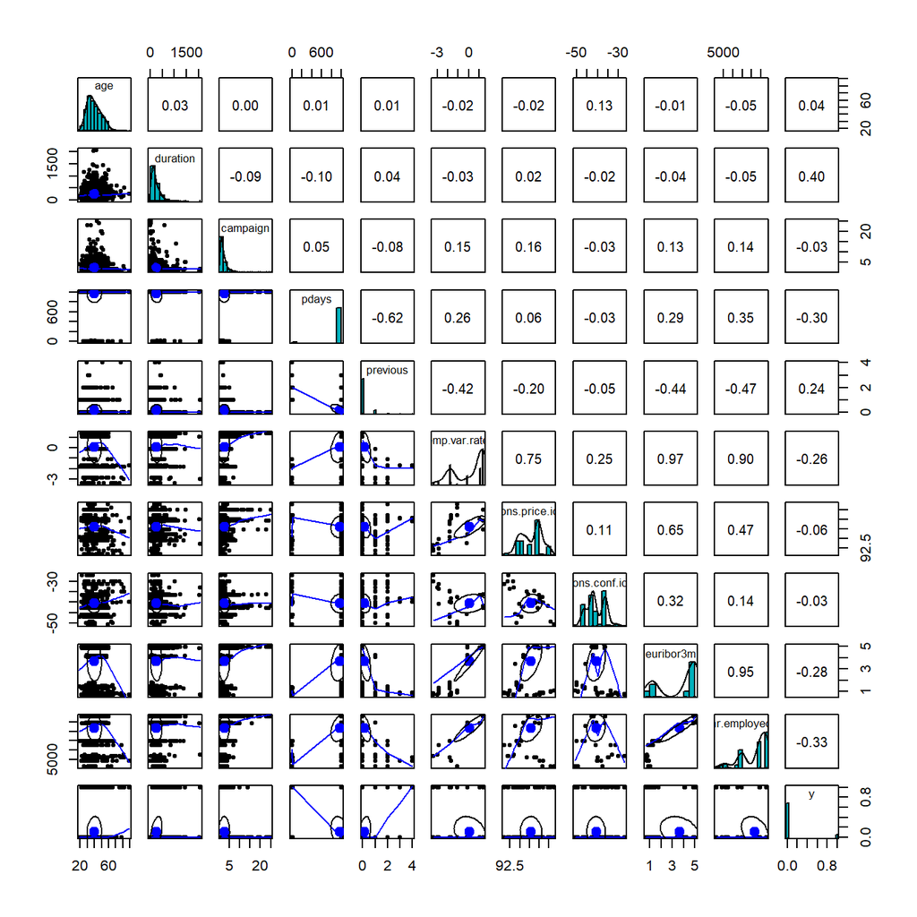

```r
numeric_vars <- sapply(bankdata.small, is.numeric)
pairs.panels(bankdata.small[, numeric_vars],
             method = "pearson",
             hist.col = "#00AFBB",
             density = TRUE,
             ellipses = TRUE)
```

From the correlation matrix plot, we can see several patterns in the predictor variables.

- Not all predictor variables are unimodal. **Campaign** and **Duration** are significantly skewed. We next take a close look at the frequency distribution of these two variables.

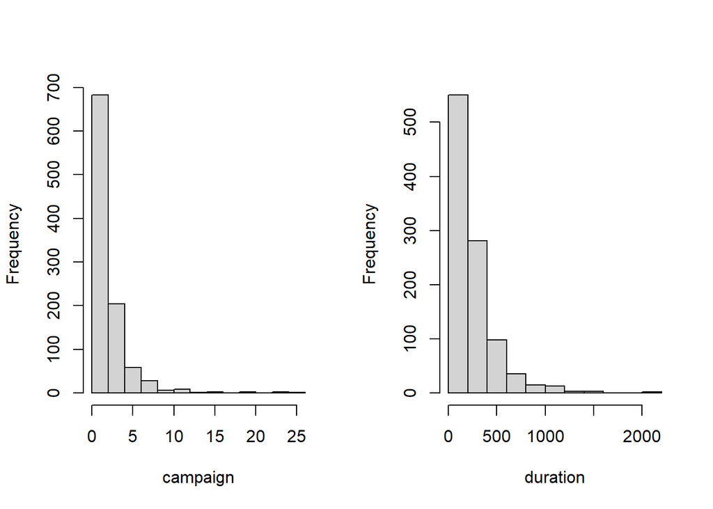

```r
par(mfrow=c(1,2))
hist(bankdata.small$campaign, xlab="campaign", main = "")
hist(bankdata.small$duration, xlab = "duration", main = "")
```

Based on the above histogram and the best clinical practices, we discretize **campaign** and **duration** in the following.

```r
cam = bankdata.small$campaign
grp.cam = cam
grp.cam[cam %in% c(0:5)] = "0-5"
grp.cam[cam %in% c(5:10)] = "5-10"
grp.cam[cam %in% c(10:50)] = "10+"
##
dur = bankdata.small$duration
##
grp.dur = dur
grp.dur[dur %in% c(0:500)] = "0-500"
grp.dur[dur %in% c(500:700)] = "500-700"
grp.dur[dur %in% c(700:800)] = "700-800"
grp.dur[dur %in% c(800:1000)] = "800-1000"
grp.dur[dur %in% c(1000:2100)] = "1000+"
## added to the diabetes data set
bankdata.small$grp.dur = grp.dur
bankdata.small$grp.cam = grp.cam
```

- A strong correlation is observed in several pairs of variables: **Emp.var.rate** v.s. **Euribor3m**, **Euribor3m** v.s. **Nr.employed**, and **Nr.employed** v.s. **Emp.var.rate**. We will not drop any of these variables for the moment but will perform an automatic variable selection process to remove potential redundant variables since a few of them will be forced to be included in the final model.
- Since our goal is association analysis, we will not perform variable transformations for the time being.

# 2 Building the Multiple Logistic Regression Model

Based on the exploratory analysis above, the two engineered variables will be used in the following model building. We adopt the convention of defining a scope for the logistic model and then using automatic model selection to identify the optimal model within that scope.

## 2.1 The Biggest Model

```r
full.model <- glm(y ~ grp.cam + emp.var.rate + euribor3m + nr.employed + grp.dur,
                  family = binomial, data = bankdata.small)


pander(summary(full.model)$coef,
      caption="Summary of inferential statistics of the full model")
```

Summary of inferential statistics of the full model

|  | Estimate | Std. Error | z value | Pr(>\|z\|) |
| --- | --- | --- | --- | --- |
| **(Intercept)** | 85.67 | 20.39 | 4.201 | 2.659e-05 |
| **grp.cam10+** | 0.9075 | 0.878 | 1.034 | 0.3013 |
| **grp.cam5-10** | 0.3792 | 0.4204 | 0.9019 | 0.3671 |
| **emp.var.rate** | -0.1341 | 0.278 | -0.4822 | 0.6296 |
| **euribor3m** | 0.1762 | 0.3497 | 0.5039 | 0.6143 |
| **nr.employed** | -0.01734 | 0.004136 | -4.192 | 2.761e-05 |
| **grp.dur1000+** | 2.849 | 0.5309 | 5.367 | 8.021e-08 |
| **grp.dur500-700** | 2.916 | 0.3725 | 7.828 | 4.94e-15 |
| **grp.dur700-800** | 2.025 | 0.9177 | 2.207 | 0.02732 |
| **grp.dur800-1000** | 4.255 | 0.6247 | 6.812 | 9.643e-12 |

Before creating the reduced model, we explore potential multicollinearity among the predictor variables. The following table shows the VIF for each individual variable.

```r
vif(full.model)
```

```
                  GVIF Df GVIF^(1/(2*Df))
grp.cam       1.088144  2        1.021343
emp.var.rate 13.152978  1        3.626703
euribor3m    27.416841  1        5.236109
nr.employed   8.449164  1        2.906745
grp.dur       1.370903  4        1.040222
```

## 2.2 Reduced Model

In applied settings, it is often necessary to include variables of practical importance in a final model, even if they lack statistical significance. Based on prior clinical knowledge, the variables `euribor3m`,`emp.var.rate`, `nr.employed` are considered plausible predictors in this deposit study, as they are macroeconomic indicators that can influence customers’ willingness to invest in a term deposit . Consequently, the 3 variables will be forced into the final model, defining the minimal adequate model.

```r
reduced.model <- glm(y ~ emp.var.rate + nr.employed + euribor3m,
                     family = binomial, data = bankdata.small)


pander(summary(reduced.model)$coef,
      caption="Summary of inferential statistics of the reduced model")
```

Summary of inferential statistics of the reduced model

|  | Estimate | Std. Error | z value | Pr(>\|z\|) |
| --- | --- | --- | --- | --- |
| **(Intercept)** | 75.03 | 18.12 | 4.14 | 3.467e-05 |
| **emp.var.rate** | -0.03795 | 0.2525 | -0.1503 | 0.8805 |
| **nr.employed** | -0.01511 | 0.003671 | -4.116 | 3.851e-05 |
| **euribor3m** | 0.1693 | 0.3113 | 0.5439 | 0.5865 |

## 2.3 Automatical Model Selection

The reduced model may use insufficient information, resulting in underfitting (missing important effects), while the full model can lead to overfitting (modeling noise and failing to generalize). To address this, we use automatic variable selection to find a simpler, more interpretable, and better-performing model by intelligently choosing a subset of predictors that includes the important variables from the reduced model while avoiding the noise of the full model.

```r
final.model.forward = stepAIC(reduced.model,
                      scope = list(lower=formula(reduced.model),upper=formula(full.model)),
                      direction = "forward",   # forward selection
                      trace = 0   # do not show the details
                      )
pander(summary(final.model.forward)$coef,
      caption="Summary of inferential statistics of the final model")
```

Summary of inferential statistics of the final model

|  | Estimate | Std. Error | z value | Pr(>\|z\|) |
| --- | --- | --- | --- | --- |
| **(Intercept)** | 83.58 | 20.23 | 4.132 | 3.598e-05 |
| **emp.var.rate** | -0.1013 | 0.2768 | -0.3659 | 0.7144 |
| **nr.employed** | -0.0169 | 0.004101 | -4.121 | 3.771e-05 |
| **euribor3m** | 0.145 | 0.3475 | 0.4174 | 0.6764 |
| **grp.dur1000+** | 2.874 | 0.5353 | 5.369 | 7.931e-08 |
| **grp.dur500-700** | 2.895 | 0.3699 | 7.828 | 4.94e-15 |
| **grp.dur700-800** | 1.98 | 0.9128 | 2.169 | 0.03005 |
| **grp.dur800-1000** | 4.178 | 0.6187 | 6.752 | 1.453e-11 |

## 2.4 Performance Comparison

We next use deviance and AIC as measures to assess the performance of the above three models. The model with the lowest AIC value is generally preferred, as it indicates a superior balance between goodness-of-fit and model complexity, penalizing unnecessary parameters. Similarly, an analysis of deviance, which measures the discrepancy between the model and the observed data, allows us to perform likelihood-ratio tests to formally compare nested models. By examining these two criteria together, we can identify the most parsimonious model that best explains the underlying structure of the data without overfitting.

```r
## Other global goodness-of-fit
global.measure=function(s.logit){
dev.resid = s.logit$deviance
dev.0.resid = s.logit$null.deviance
aic = s.logit$aic
goodness = cbind(Deviance.residual =dev.resid, Null.Deviance.Residual = dev.0.resid,
      AIC = aic)
goodness
}
goodness=rbind(full.model = global.measure(full.model),
      reduced.model=global.measure(reduced.model),
      final.model=global.measure(final.model.forward))
row.names(goodness) = c("full.model", "reduced.model", "auto.selected.model")
pander(goodness, caption ="Comparison of global goodness-of-fit statistics")
```

Comparison of global goodness-of-fit statistics

|  | Deviance.residual | Null.Deviance.Residual | AIC |
| --- | --- | --- | --- |
| **full.model** | 466.6 | 676.1 | 486.6 |
| **reduced.model** | 583.2 | 676.1 | 591.2 |
| **auto.selected.model** | 468.2 | 676.1 | 484.2 |

The above results shows that

- The **auto.selected.model** has the smallest AIC, but it could be underfitted.
- The **full.model** and the **auto.selected.model** are have similar **residual deviance**.

We next use the likelihood ratio chi-squared test to see whether the the **full.model** and the **auto.selected.model** are significantly different.

The chi-square test statistic is defined to be

$$\text{Residual.Deviance}_{\text{auto.selected.model}} -
\text{Residual.Deviance}_{\text{full.model}} = 468.2-466.6 = 1.6.$$

The degrees of freedom is

$$DF = \text{Num of variables in the full.model} - \text{Num of variables
in the auto.selected.model} = 10-8 = 2$$

The p-value of the above likelihood ratio test is given by

$$\text{p-value} = P(\chi^2_2 > 1.6) = 0.449$$

Since the p-value indicates that the two models are not statistically different, we select the **auto.selected.model** as our final model in accordance with the principle of parsimony.

# 3 Final Model

```r
# Odds ratio
model.coef.stats = summary(final.model.forward)$coef
odds.ratio = exp(coef(final.model.forward))
out.stats = cbind(model.coef.stats, odds.ratio = odds.ratio)
kable(out.stats,caption = "Summary Stats with Odds Ratios")
```

Summary Stats with Odds Ratios

|  | Estimate | Std. Error | z value | Pr(>\|z\|) | odds.ratio |
| --- | --- | --- | --- | --- | --- |
| (Intercept) | 83.5763152 | 20.2270647 | 4.1319053 | 0.0000360 | 1.980307e+36 |
| emp.var.rate | -0.1012853 | 0.2767873 | -0.3659317 | 0.7144161 | 9.036752e-01 |
| nr.employed | -0.0169008 | 0.0041011 | -4.1210855 | 0.0000377 | 9.832412e-01 |
| euribor3m | 0.1450385 | 0.3474565 | 0.4174292 | 0.6763645 | 1.156084e+00 |
| grp.dur1000+ | 2.8737377 | 0.5352778 | 5.3686846 | 0.0000001 | 1.770306e+01 |
| grp.dur500-700 | 2.8953455 | 0.3698506 | 7.8284190 | 0.0000000 | 1.808975e+01 |
| grp.dur700-800 | 1.9801979 | 0.9127855 | 2.1694012 | 0.0300522 | 7.244177e+00 |
| grp.dur800-1000 | 4.1778461 | 0.6187110 | 6.7524998 | 0.0000000 | 6.522521e+01 |

## 3.1 Summary and Conclusion

The case study focused on the association analysis between a set of potential risk factors for if a client will subscribe a term deposit. The initial data set has 10 numeric variables and 11 categorical variables.

After exploratory analysis, we decide to re-group two sparse discrete variables **campaign** and **duration**, and then define dummy variables for the associated variables. These new group variables were used in the model search process.

After automatic variable selection, we obtain the final model with 4 factors, duration, emp.var.rate, nr.employed, euribor3m (with 4 dummy variables).